# OUTPUT

[output not shown]

Log  
Log - Log - July 26, 2017

* Decision Tree.  
TREE CreditRating [n] BY MortgageType [n] LoanBalance [s] InterestType [n] NewLoan [n]  
ProbationaryLoans [n] InterestIncome [s] PropertyValue [s] AnnualPYMT [s] DefaultedLoans [n]  
AddressLatitude [s] AddressLongitude [s] County [n] LTV [s] ArrearsCategory [n] MortgageYears [s]  
InArrears [n]  
/TREE DISPLAY=TOPDOWN NODES=STATISTICS BRANCHSTATISTICS=YES NODEDEFS=YES SCALE=AUTO  
/DEPCATEGORIES USEVALUES=[VALID]  
/PRINT MODELSUMMARY CLASSIFICATION RISK CATEGORYSPECS  
/METHOD TYPE=CHAID  
/GROWTHLIMIT MAXDEPTH=AUTO MINPARENTSIZE=100 MINCHILDSIZE=50  
/VALIDATION TYPE=SPLITSAMPLE(70) OUTPUT=BOTHSAMPLES  
/CHAID ALPHASPLIT=0.05 ALPHAMERGE=0.05 SPLITMERGED=NO CHISQUARE=PEARSON CONVERGE=0.001  
MAXITERATIONS=100 ADJUST=BONFERRONI INTERVALS=10  
/COSTS EQUAL  
/MISSING NOMINALMISSING=MISSING.

Classification Tree  
Classification Tree - Notes - July 26, 2017

NotesNotes, table, 0 levels of column headers and 2 levels of row headers, table with 3 columns and 14 rows

| Output Created |  | 26-JUL-2017 21:01:10 |
| --- | --- | --- |
| Comments |  |  |
| Input | Active Dataset | DataSet1 |
|  | Filter | <none> |
|  | Weight | <none> |
|  | Split File | <none> |
|  | N of Rows in Working Data File | 237389 |
| Missing Value Handling | Definition of Missing | Handling of user-defined missing values of nominal independent variables depends on the growing method. |
|  | Cases Used | Only cases with valid data for the dependent variable and some or all independent variables are used in computing any statistics. |
| Syntax |  | TREE CreditRating [n] BY MortgageType [n] LoanBalance [s] InterestType [n] NewLoan [n] ProbationaryLoans [n] InterestIncome [s] PropertyValue [s] AnnualPYMT [s] DefaultedLoans [n] AddressLatitude [s] … |
| Resources | Processor Time | 00:00:27.06 |
|  | Elapsed Time | 00:00:30.84 |
| Files Saved | Rules File |  |

Classification Tree  
Classification Tree - Warnings - July 26, 2017

WarningsWarnings, table, 0 levels of column headers and 0 levels of row headers, table with 1 columns and 6 rows

| The table of scores is not displayed because the dependent variable is not ordinal. |
| --- |
| The table of priors is not displayed because the growing method is not QUEST or CRT. |
| The table of profits is not displayed because profits are not defined. |
| Gain summary Tables are not displayed because profits are undefined. |
| Target category gains tables are not displayed because target categories are undefined. |

Classification Tree  
Classification Tree - Model Summary - July 26, 2017

Model SummaryModel Summary, table, 0 levels of column headers and 2 levels of row headers, table with 3 columns and 12 rows

| Specifications | Growing Method | CHAID |
| --- | --- | --- |
|  | Dependent Variable | CreditRating |
|  | Independent Variables | MortgageType, LoanBalance, InterestType, NewLoan, ProbationaryLoans, InterestIncome, PropertyValue, AnnualPYMT, DefaultedLoans, AddressLatitude, AddressLongitude, County, LTV, ArrearsCategory, Mortgag… |
|  | Validation | Split Sample |
|  | Maximum Tree Depth | 3 |
|  | Minimum Cases in Parent Node | 100 |
|  | Minimum Cases in Child Node | 50 |
| Results | Independent Variables Included | DefaultedLoans, ProbationaryLoans, MortgageType, LTV |
|  | Number of Nodes | 15 |
|  | Number of Terminal Nodes | 9 |
|  | Depth | 3 |

Classification Tree  
Classification Tree - Misclassification Costs - July 26, 2017

Misclassification CostsMisclassification Costs, table, 2 levels of column headers and 1 levels of row headers, table with 6 columns and 9 rows

| Observed | Predicted |  |  |  |  |
| --- | --- | --- | --- | --- | --- |
|  | 1 | 2 | 3 | 4 | 5 |
| 1 | .000 | 1.000 | 1.000 | 1.000 | 1.000 |
| 2 | 1.000 | .000 | 1.000 | 1.000 | 1.000 |
| 3 | 1.000 | 1.000 | .000 | 1.000 | 1.000 |
| 4 | 1.000 | 1.000 | 1.000 | .000 | 1.000 |
| 5 | 1.000 | 1.000 | 1.000 | 1.000 | .000 |

Dependent Variable: CreditRating

Training Sample  
Training Sample - Tree Diagram - July 26, 2017

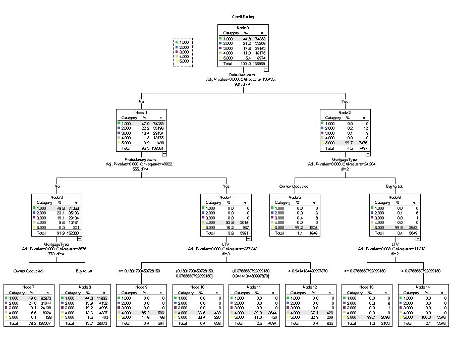

Test Sample  
Test Sample - Tree Diagram - July 26, 2017

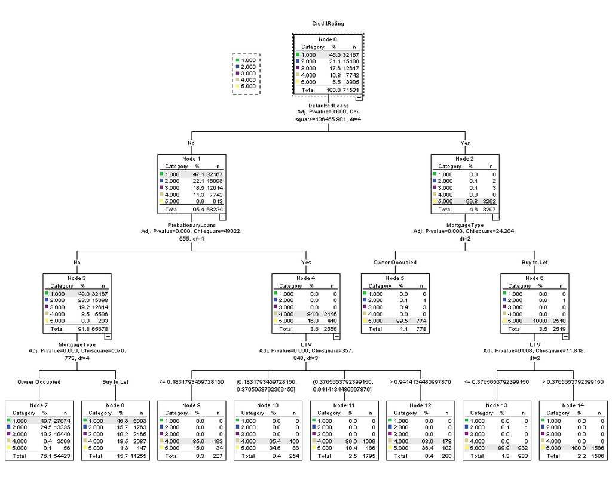

Classification Tree  
Classification Tree - Risk - July 26, 2017

RiskRisk, table, 1 levels of column headers and 1 levels of row headers, table with 3 columns and 5 rows

| Sample | Estimate | Std. Error |
| --- | --- | --- |
| Training | .476 | .001 |
| Test | .474 | .002 |

Growing Method: CHAID Dependent Variable: CreditRating

Classification Tree  
Classification Tree - Classification - July 26, 2017

ClassificationClassification, table, 2 levels of column headers and 2 levels of row headers, table with 8 columns and 16 rows

| Sample | Observed | Predicted |  |  |  |  |  |
| --- | --- | --- | --- | --- | --- | --- | --- |
|  |  | 1 | 2 | 3 | 4 | 5 | Percent Correct |
| Training | 1 | 74358 | 0 | 0 | 0 | 0 | 100.0% |
|  | 2 | 35196 | 0 | 0 | 0 | 12 | 0.0% |
|  | 3 | 29134 | 0 | 0 | 0 | 9 | 0.0% |
|  | 4 | 13161 | 0 | 0 | 5014 | 0 | 27.6% |
|  | 5 | 531 | 0 | 0 | 967 | 7476 | 83.3% |
|  | Overall Percentage | 91.9% | 0.0% | 0.0% | 3.6% | 4.5% | 52.4% |
| Test | 1 | 32167 | 0 | 0 | 0 | 0 | 100.0% |
|  | 2 | 15098 | 0 | 0 | 0 | 2 | 0.0% |
|  | 3 | 12614 | 0 | 0 | 0 | 3 | 0.0% |
|  | 4 | 5596 | 0 | 0 | 2146 | 0 | 27.7% |
|  | 5 | 203 | 0 | 0 | 410 | 3292 | 84.3% |
|  | Overall Percentage | 91.8% | 0.0% | 0.0% | 3.6% | 4.6% | 52.6% |

Growing Method: CHAID Dependent Variable: CreditRating

Log  
Log - Log - July 26, 2017

* Decision Tree.  
TREE DefaultedLoans [n] BY MortgageType [n] LoanBalance [s] InterestType [n] NewLoan [n]  
ProbationaryLoans [n] InterestIncome [s] PropertyValue [s] AnnualPYMT [s] AddressLatitude [s]  
AddressLongitude [s] County [n] LTV [s] ArrearsCategory [n] MortgageYears [s] InArrears [n]  
CreditRating [n]  
/TREE DISPLAY=TOPDOWN NODES=STATISTICS BRANCHSTATISTICS=YES NODEDEFS=YES SCALE=AUTO  
/DEPCATEGORIES USEVALUES=[VALID]  
/PRINT MODELSUMMARY CLASSIFICATION RISK CATEGORYSPECS  
/METHOD TYPE=CHAID  
/GROWTHLIMIT MAXDEPTH=9 MINPARENTSIZE=100 MINCHILDSIZE=50  
/VALIDATION TYPE=SPLITSAMPLE(70) OUTPUT=BOTHSAMPLES  
/CHAID ALPHASPLIT=0.05 ALPHAMERGE=0.05 SPLITMERGED=NO CHISQUARE=PEARSON CONVERGE=0.001  
MAXITERATIONS=100 ADJUST=BONFERRONI INTERVALS=10  
/COSTS EQUAL  
/MISSING NOMINALMISSING=MISSING.

Classification Tree  
Classification Tree - Notes - July 26, 2017

NotesNotes, table, 0 levels of column headers and 2 levels of row headers, table with 3 columns and 14 rows

| Output Created |  | 26-JUL-2017 21:06:06 |
| --- | --- | --- |
| Comments |  |  |
| Input | Active Dataset | DataSet1 |
|  | Filter | <none> |
|  | Weight | <none> |
|  | Split File | <none> |
|  | N of Rows in Working Data File | 237389 |
| Missing Value Handling | Definition of Missing | Handling of user-defined missing values of nominal independent variables depends on the growing method. |
|  | Cases Used | Only cases with valid data for the dependent variable and some or all independent variables are used in computing any statistics. |
| Syntax |  | TREE DefaultedLoans [n] BY MortgageType [n] LoanBalance [s] InterestType [n] NewLoan [n] ProbationaryLoans [n] InterestIncome [s] PropertyValue [s] AnnualPYMT [s] AddressLatitude [s] AddressLongitude … |
| Resources | Processor Time | 00:00:26.11 |
|  | Elapsed Time | 00:00:26.62 |
| Files Saved | Rules File |  |

Classification Tree  
Classification Tree - Warnings - July 26, 2017

WarningsWarnings, table, 0 levels of column headers and 0 levels of row headers, table with 1 columns and 6 rows

| The table of scores is not displayed because the dependent variable is not ordinal. |
| --- |
| The table of priors is not displayed because the growing method is not QUEST or CRT. |
| The table of profits is not displayed because profits are not defined. |
| Gain summary Tables are not displayed because profits are undefined. |
| Target category gains tables are not displayed because target categories are undefined. |

Classification Tree  
Classification Tree - Model Summary - July 26, 2017

Model SummaryModel Summary, table, 0 levels of column headers and 2 levels of row headers, table with 3 columns and 12 rows

| Specifications | Growing Method | CHAID |
| --- | --- | --- |
|  | Dependent Variable | DefaultedLoans |
|  | Independent Variables | MortgageType, LoanBalance, InterestType, NewLoan, ProbationaryLoans, InterestIncome, PropertyValue, AnnualPYMT, AddressLatitude, AddressLongitude, County, LTV, ArrearsCategory, MortgageYears, InArrear… |
|  | Validation | Split Sample |
|  | Maximum Tree Depth | 9 |
|  | Minimum Cases in Parent Node | 100 |
|  | Minimum Cases in Child Node | 50 |
| Results | Independent Variables Included | CreditRating, LTV, PropertyValue, MortgageYears, AddressLongitude, AnnualPYMT, ProbationaryLoans, InterestType, LoanBalance |
|  | Number of Nodes | 34 |
|  | Number of Terminal Nodes | 21 |
|  | Depth | 5 |

Classification Tree  
Classification Tree - Misclassification Costs - July 26, 2017

Misclassification CostsMisclassification Costs, table, 2 levels of column headers and 1 levels of row headers, table with 3 columns and 6 rows

| Observed | Predicted |  |
| --- | --- | --- |
|  | No | Yes |
| No | .000 | 1.000 |
| Yes | 1.000 | .000 |

Dependent Variable: DefaultedLoans

Training Sample  
Training Sample - Tree Diagram - July 26, 2017

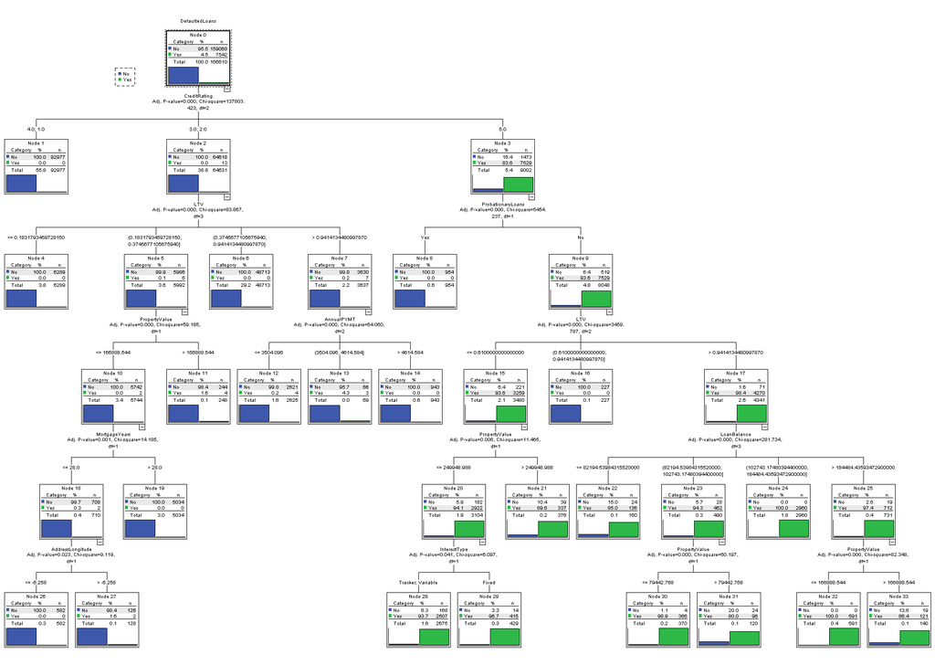

Test Sample  
Test Sample - Tree Diagram - July 26, 2017

[figure not shown]

Classification Tree  
Classification Tree - Risk - July 26, 2017

RiskRisk, table, 1 levels of column headers and 1 levels of row headers, table with 3 columns and 5 rows

| Sample | Estimate | Std. Error |
| --- | --- | --- |
| Training | .002 | .000 |
| Test | .002 | .000 |

Growing Method: CHAID Dependent Variable: DefaultedLoans

Classification Tree  
Classification Tree - Classification - July 26, 2017

ClassificationClassification, table, 2 levels of column headers and 2 levels of row headers, table with 5 columns and 10 rows

| Sample | Observed | Predicted |  |  |
| --- | --- | --- | --- | --- |
|  |  | No | Yes | Percent Correct |
| Training | No | 158776 | 292 | 99.8% |
|  | Yes | 13 | 7529 | 99.8% |
|  | Overall Percentage | 95.3% | 4.7% | 99.8% |
| Test | No | 67411 | 116 | 99.8% |
|  | Yes | 13 | 3239 | 99.6% |
|  | Overall Percentage | 95.3% | 4.7% | 99.8% |

Growing Method: CHAID Dependent Variable: DefaultedLoans

Log  
Log - Log - July 26, 2017

* Decision Tree.  
TREE DefaultedLoans [n] BY MortgageType [n] LoanBalance [s] InterestType [n] NewLoan [n]  
ProbationaryLoans [n] InterestIncome [s] PropertyValue [s] AnnualPYMT [s] AddressLatitude [s]  
AddressLongitude [s] County [n] LTV [s] ArrearsCategory [n] MortgageYears [s] InArrears [n]  
/TREE DISPLAY=TOPDOWN NODES=STATISTICS BRANCHSTATISTICS=YES NODEDEFS=YES SCALE=AUTO  
/DEPCATEGORIES USEVALUES=[VALID]  
/PRINT MODELSUMMARY CLASSIFICATION RISK CATEGORYSPECS  
/METHOD TYPE=CHAID  
/GROWTHLIMIT MAXDEPTH=9 MINPARENTSIZE=100 MINCHILDSIZE=50  
/VALIDATION TYPE=SPLITSAMPLE(70) OUTPUT=BOTHSAMPLES  
/CHAID ALPHASPLIT=0.05 ALPHAMERGE=0.05 SPLITMERGED=NO CHISQUARE=PEARSON CONVERGE=0.001  
MAXITERATIONS=100 ADJUST=BONFERRONI INTERVALS=10  
/COSTS EQUAL  
/INFLUENCE CreditRating  
/MISSING NOMINALMISSING=MISSING.

Classification Tree  
Classification Tree - Notes - July 26, 2017

NotesNotes, table, 0 levels of column headers and 2 levels of row headers, table with 3 columns and 15 rows

| Output Created |  | 26-JUL-2017 21:17:52 |
| --- | --- | --- |
| Comments |  |  |
| Input | Active Dataset | DataSet1 |
|  | Filter | <none> |
|  | Weight | <none> |
|  | Split File | <none> |
|  | N of Rows in Working Data File | 237389 |
|  | Influence Variable | CreditRating |
| Missing Value Handling | Definition of Missing | Handling of user-defined missing values of nominal independent variables depends on the growing method. |
|  | Cases Used | Only cases with valid data for the dependent variable and some or all independent variables are used in computing any statistics. |
| Syntax |  | TREE DefaultedLoans [n] BY MortgageType [n] LoanBalance [s] InterestType [n] NewLoan [n] ProbationaryLoans [n] InterestIncome [s] PropertyValue [s] AnnualPYMT [s] AddressLatitude [s] AddressLongitude … |
| Resources | Processor Time | 00:00:30.17 |
|  | Elapsed Time | 00:00:33.32 |
| Files Saved | Rules File |  |

Classification Tree  
Classification Tree - Warnings - July 26, 2017

WarningsWarnings, table, 0 levels of column headers and 0 levels of row headers, table with 1 columns and 6 rows

| The table of scores is not displayed because the dependent variable is not ordinal. |
| --- |
| The table of priors is not displayed because the growing method is not QUEST or CRT. |
| The table of profits is not displayed because profits are not defined. |
| Gain summary Tables are not displayed because profits are undefined. |
| Target category gains tables are not displayed because target categories are undefined. |

Classification Tree  
Classification Tree - Model Summary - July 26, 2017

Model SummaryModel Summary, table, 0 levels of column headers and 2 levels of row headers, table with 3 columns and 12 rows

| Specifications | Growing Method | CHAID |
| --- | --- | --- |
|  | Dependent Variable | DefaultedLoans |
|  | Independent Variables | MortgageType, LoanBalance, InterestType, NewLoan, ProbationaryLoans, InterestIncome, PropertyValue, AnnualPYMT, AddressLatitude, AddressLongitude, County, LTV, ArrearsCategory, MortgageYears, InArrear… |
|  | Validation | Split Sample |
|  | Maximum Tree Depth | 9 |
|  | Minimum Cases in Parent Node | 100 |
|  | Minimum Cases in Child Node | 50 |
| Results | Independent Variables Included | LTV, MortgageType, InterestIncome, ProbationaryLoans, AddressLatitude, AddressLongitude, AnnualPYMT, InterestType, ArrearsCategory, LoanBalance, County, PropertyValue, InArrears, MortgageYears, NewLoa… |
|  | Number of Nodes | 328 |
|  | Number of Terminal Nodes | 200 |
|  | Depth | 9 |

Classification Tree  
Classification Tree - Misclassification Costs - July 26, 2017

Misclassification CostsMisclassification Costs, table, 2 levels of column headers and 1 levels of row headers, table with 3 columns and 6 rows

| Observed | Predicted |  |
| --- | --- | --- |
|  | No | Yes |
| No | .000 | 1.000 |
| Yes | 1.000 | .000 |

Dependent Variable: DefaultedLoans

Training Sample  
Training Sample - Tree Diagram - July 26, 2017

[figure not shown]

Test Sample  
Test Sample - Tree Diagram - July 26, 2017

[figure not shown]

Classification Tree  
Classification Tree - Risk - July 26, 2017

RiskRisk, table, 1 levels of column headers and 1 levels of row headers, table with 3 columns and 5 rows

| Sample | Estimate | Std. Error |
| --- | --- | --- |
| Training | .017 | .000 |
| Test | .018 | .000 |

Growing Method: CHAID Dependent Variable: DefaultedLoans

Classification Tree  
Classification Tree - Classification - July 26, 2017

ClassificationClassification, table, 2 levels of column headers and 2 levels of row headers, table with 5 columns and 10 rows

| Sample | Observed | Predicted |  |  |
| --- | --- | --- | --- | --- |
|  |  | No | Yes | Percent Correct |
| Training | No | 157436 | 1051 | 99.3% |
|  | Yes | 1727 | 5845 | 77.2% |
|  | Overall Percentage | 95.8% | 4.2% | 98.3% |
| Test | No | 67565 | 543 | 99.2% |
|  | Yes | 735 | 2487 | 77.2% |
|  | Overall Percentage | 95.8% | 4.2% | 98.2% |

Growing Method: CHAID Dependent Variable: DefaultedLoans

Log  
Log - Log - July 26, 2017

* Decision Tree.  
TREE DefaultedLoans [n] BY MortgageType [n] LoanBalance [s] InterestType [n] NewLoan [n]  
ProbationaryLoans [n] InterestIncome [s] PropertyValue [s] AnnualPYMT [s] AddressLatitude [s]  
AddressLongitude [s] County [n] LTV [s] ArrearsCategory [n] MortgageYears [s] InArrears [n]  
/TREE DISPLAY=TOPDOWN NODES=STATISTICS BRANCHSTATISTICS=YES NODEDEFS=YES SCALE=AUTO  
/DEPCATEGORIES USEVALUES=[VALID]  
/PRINT MODELSUMMARY CLASSIFICATION RISK CATEGORYSPECS  
/METHOD TYPE=CHAID  
/GROWTHLIMIT MAXDEPTH=6 MINPARENTSIZE=100 MINCHILDSIZE=50  
/VALIDATION TYPE=SPLITSAMPLE(70) OUTPUT=BOTHSAMPLES  
/CHAID ALPHASPLIT=0.05 ALPHAMERGE=0.05 SPLITMERGED=NO CHISQUARE=PEARSON CONVERGE=0.001  
MAXITERATIONS=100 ADJUST=BONFERRONI INTERVALS=10  
/COSTS EQUAL  
/INFLUENCE CreditRating  
/MISSING NOMINALMISSING=MISSING.

Classification Tree  
Classification Tree - Notes - July 26, 2017

NotesNotes, table, 0 levels of column headers and 2 levels of row headers, table with 3 columns and 15 rows

| Output Created |  | 26-JUL-2017 21:27:19 |
| --- | --- | --- |
| Comments |  |  |
| Input | Active Dataset | DataSet1 |
|  | Filter | <none> |
|  | Weight | <none> |
|  | Split File | <none> |
|  | N of Rows in Working Data File | 237389 |
|  | Influence Variable | CreditRating |
| Missing Value Handling | Definition of Missing | Handling of user-defined missing values of nominal independent variables depends on the growing method. |
|  | Cases Used | Only cases with valid data for the dependent variable and some or all independent variables are used in computing any statistics. |
| Syntax |  | TREE DefaultedLoans [n] BY MortgageType [n] LoanBalance [s] InterestType [n] NewLoan [n] ProbationaryLoans [n] InterestIncome [s] PropertyValue [s] AnnualPYMT [s] AddressLatitude [s] AddressLongitude … |
| Resources | Processor Time | 00:00:25.23 |
|  | Elapsed Time | 00:00:28.46 |
| Files Saved | Rules File |  |

Classification Tree  
Classification Tree - Warnings - July 26, 2017

WarningsWarnings, table, 0 levels of column headers and 0 levels of row headers, table with 1 columns and 6 rows

| The table of scores is not displayed because the dependent variable is not ordinal. |
| --- |
| The table of priors is not displayed because the growing method is not QUEST or CRT. |
| The table of profits is not displayed because profits are not defined. |
| Gain summary Tables are not displayed because profits are undefined. |
| Target category gains tables are not displayed because target categories are undefined. |

Classification Tree  
Classification Tree - Model Summary - July 26, 2017

Model SummaryModel Summary, table, 0 levels of column headers and 2 levels of row headers, table with 3 columns and 12 rows

| Specifications | Growing Method | CHAID |
| --- | --- | --- |
|  | Dependent Variable | DefaultedLoans |
|  | Independent Variables | MortgageType, LoanBalance, InterestType, NewLoan, ProbationaryLoans, InterestIncome, PropertyValue, AnnualPYMT, AddressLatitude, AddressLongitude, County, LTV, ArrearsCategory, MortgageYears, InArrear… |
|  | Validation | Split Sample |
|  | Maximum Tree Depth | 6 |
|  | Minimum Cases in Parent Node | 100 |
|  | Minimum Cases in Child Node | 50 |
| Results | Independent Variables Included | LTV, MortgageType, ProbationaryLoans, AnnualPYMT, LoanBalance, County, AddressLongitude, InterestIncome, ArrearsCategory, AddressLatitude, MortgageYears, PropertyValue, InterestType, NewLoan |
|  | Number of Nodes | 276 |
|  | Number of Terminal Nodes | 173 |
|  | Depth | 6 |

Classification Tree  
Classification Tree - Misclassification Costs - July 26, 2017

Misclassification CostsMisclassification Costs, table, 2 levels of column headers and 1 levels of row headers, table with 3 columns and 6 rows

| Observed | Predicted |  |
| --- | --- | --- |
|  | No | Yes |
| No | .000 | 1.000 |
| Yes | 1.000 | .000 |

Dependent Variable: DefaultedLoans

Training Sample  
Training Sample - Tree Diagram - July 26, 2017

[figure not shown]

Test Sample  
Test Sample - Tree Diagram - July 26, 2017

[figure not shown]

Classification Tree  
Classification Tree - Risk - July 26, 2017

RiskRisk, table, 1 levels of column headers and 1 levels of row headers, table with 3 columns and 5 rows

| Sample | Estimate | Std. Error |
| --- | --- | --- |
| Training | .016 | .000 |
| Test | .017 | .000 |

Growing Method: CHAID Dependent Variable: DefaultedLoans

Classification Tree  
Classification Tree - Classification - July 26, 2017

ClassificationClassification, table, 2 levels of column headers and 2 levels of row headers, table with 5 columns and 10 rows

| Sample | Observed | Predicted |  |  |
| --- | --- | --- | --- | --- |
|  |  | No | Yes | Percent Correct |
| Training | No | 157822 | 903 | 99.4% |
|  | Yes | 1774 | 5852 | 76.7% |
|  | Overall Percentage | 95.9% | 4.1% | 98.4% |
| Test | No | 67478 | 392 | 99.4% |
|  | Yes | 800 | 2368 | 74.7% |
|  | Overall Percentage | 96.1% | 3.9% | 98.3% |

Growing Method: CHAID Dependent Variable: DefaultedLoans

Log  
Log - Log - July 26, 2017

* Decision Tree.  
TREE DefaultedLoans [n] BY MortgageType [n] LoanBalance [s] InterestType [n] NewLoan [n]  
ProbationaryLoans [n] InterestIncome [s] PropertyValue [s] AnnualPYMT [s] AddressLatitude [s]  
AddressLongitude [s] County [n] LTV [s] ArrearsCategory [n] MortgageYears [s] InArrears [n]  
/TREE DISPLAY=TOPDOWN NODES=STATISTICS BRANCHSTATISTICS=YES NODEDEFS=YES SCALE=AUTO  
/DEPCATEGORIES USEVALUES=[VALID]  
/PRINT MODELSUMMARY CLASSIFICATION RISK CATEGORYSPECS  
/METHOD TYPE=CHAID  
/GROWTHLIMIT MAXDEPTH=AUTO MINPARENTSIZE=100 MINCHILDSIZE=50  
/VALIDATION TYPE=SPLITSAMPLE(70) OUTPUT=BOTHSAMPLES  
/CHAID ALPHASPLIT=0.05 ALPHAMERGE=0.05 SPLITMERGED=NO CHISQUARE=PEARSON CONVERGE=0.001  
MAXITERATIONS=100 ADJUST=BONFERRONI INTERVALS=10  
/COSTS EQUAL  
/INFLUENCE CreditRating  
/MISSING NOMINALMISSING=MISSING.

Classification Tree  
Classification Tree - Notes - July 26, 2017

NotesNotes, table, 0 levels of column headers and 2 levels of row headers, table with 3 columns and 15 rows

| Output Created |  | 26-JUL-2017 21:30:05 |
| --- | --- | --- |
| Comments |  |  |
| Input | Active Dataset | DataSet1 |
|  | Filter | <none> |
|  | Weight | <none> |
|  | Split File | <none> |
|  | N of Rows in Working Data File | 237389 |
|  | Influence Variable | CreditRating |
| Missing Value Handling | Definition of Missing | Handling of user-defined missing values of nominal independent variables depends on the growing method. |
|  | Cases Used | Only cases with valid data for the dependent variable and some or all independent variables are used in computing any statistics. |
| Syntax |  | TREE DefaultedLoans [n] BY MortgageType [n] LoanBalance [s] InterestType [n] NewLoan [n] ProbationaryLoans [n] InterestIncome [s] PropertyValue [s] AnnualPYMT [s] AddressLatitude [s] AddressLongitude … |
| Resources | Processor Time | 00:00:23.00 |
|  | Elapsed Time | 00:00:36.09 |
| Files Saved | Rules File |  |

Classification Tree  
Classification Tree - Warnings - July 26, 2017

WarningsWarnings, table, 0 levels of column headers and 0 levels of row headers, table with 1 columns and 6 rows

| The table of scores is not displayed because the dependent variable is not ordinal. |
| --- |
| The table of priors is not displayed because the growing method is not QUEST or CRT. |
| The table of profits is not displayed because profits are not defined. |
| Gain summary Tables are not displayed because profits are undefined. |
| Target category gains tables are not displayed because target categories are undefined. |

Classification Tree  
Classification Tree - Model Summary - July 26, 2017

Model SummaryModel Summary, table, 0 levels of column headers and 2 levels of row headers, table with 3 columns and 12 rows

| Specifications | Growing Method | CHAID |
| --- | --- | --- |
|  | Dependent Variable | DefaultedLoans |
|  | Independent Variables | MortgageType, LoanBalance, InterestType, NewLoan, ProbationaryLoans, InterestIncome, PropertyValue, AnnualPYMT, AddressLatitude, AddressLongitude, County, LTV, ArrearsCategory, MortgageYears, InArrear… |
|  | Validation | Split Sample |
|  | Maximum Tree Depth | 3 |
|  | Minimum Cases in Parent Node | 100 |
|  | Minimum Cases in Child Node | 50 |
| Results | Independent Variables Included | LTV, MortgageType, ProbationaryLoans, InterestIncome, PropertyValue, LoanBalance, NewLoan, AnnualPYMT |
|  | Number of Nodes | 73 |
|  | Number of Terminal Nodes | 51 |
|  | Depth | 3 |

Classification Tree  
Classification Tree - Misclassification Costs - July 26, 2017

Misclassification CostsMisclassification Costs, table, 2 levels of column headers and 1 levels of row headers, table with 3 columns and 6 rows

| Observed | Predicted |  |
| --- | --- | --- |
|  | No | Yes |
| No | .000 | 1.000 |
| Yes | 1.000 | .000 |

Dependent Variable: DefaultedLoans

Training Sample  
Training Sample - Tree Diagram - July 26, 2017

[figure not shown]

Test Sample  
Test Sample - Tree Diagram - July 26, 2017

[figure not shown]

Classification Tree  
Classification Tree - Risk - July 26, 2017

RiskRisk, table, 1 levels of column headers and 1 levels of row headers, table with 3 columns and 5 rows

| Sample | Estimate | Std. Error |
| --- | --- | --- |
| Training | .018 | .000 |
| Test | .017 | .000 |

Growing Method: CHAID Dependent Variable: DefaultedLoans

Classification Tree  
Classification Tree - Classification - July 26, 2017

ClassificationClassification, table, 2 levels of column headers and 2 levels of row headers, table with 5 columns and 10 rows

| Sample | Observed | Predicted |  |  |
| --- | --- | --- | --- | --- |
|  |  | No | Yes | Percent Correct |
| Training | No | 158011 | 824 | 99.5% |
|  | Yes | 2097 | 5513 | 72.4% |
|  | Overall Percentage | 96.2% | 3.8% | 98.2% |
| Test | No | 67367 | 393 | 99.4% |
|  | Yes | 836 | 2348 | 73.7% |
|  | Overall Percentage | 96.1% | 3.9% | 98.3% |

Growing Method: CHAID Dependent Variable: DefaultedLoans

Log  
Log - Log - July 26, 2017

* Decision Tree.  
TREE DefaultedLoans [n] BY MortgageType [n] LoanBalance [s] InterestType [n] NewLoan [n]  
ProbationaryLoans [n] InterestIncome [s] PropertyValue [s] AnnualPYMT [s] AddressLatitude [s]  
AddressLongitude [s] County [n] LTV [s] ArrearsCategory [n] MortgageYears [s] InArrears [n]  
/TREE DISPLAY=TOPDOWN NODES=STATISTICS BRANCHSTATISTICS=YES NODEDEFS=YES SCALE=AUTO  
/DEPCATEGORIES USEVALUES=[VALID]  
/PRINT MODELSUMMARY CLASSIFICATION RISK CATEGORYSPECS  
/METHOD TYPE=CRT MAXSURROGATES=AUTO PRUNE=NONE  
/GROWTHLIMIT MAXDEPTH=AUTO MINPARENTSIZE=100 MINCHILDSIZE=50  
/VALIDATION TYPE=SPLITSAMPLE(70) OUTPUT=BOTHSAMPLES  
/CRT IMPURITY=GINI MINIMPROVEMENT=0.0001  
/COSTS EQUAL  
/PRIORS FROMDATA ADJUST=NO  
/INFLUENCE CreditRating  
/MISSING NOMINALMISSING=MISSING.

Classification Tree  
Classification Tree - Notes - July 26, 2017

NotesNotes, table, 0 levels of column headers and 2 levels of row headers, table with 3 columns and 15 rows

| Output Created |  | 26-JUL-2017 21:42:19 |
| --- | --- | --- |
| Comments |  |  |
| Input | Active Dataset | DataSet1 |
|  | Filter | <none> |
|  | Weight | <none> |
|  | Split File | <none> |
|  | N of Rows in Working Data File | 237389 |
|  | Influence Variable | CreditRating |
| Missing Value Handling | Definition of Missing | Handling of user-defined missing values of nominal independent variables depends on the growing method. |
|  | Cases Used | Only cases with valid data for the dependent variable and some or all independent variables are used in computing any statistics. |
| Syntax |  | TREE DefaultedLoans [n] BY MortgageType [n] LoanBalance [s] InterestType [n] NewLoan [n] ProbationaryLoans [n] InterestIncome [s] PropertyValue [s] AnnualPYMT [s] AddressLatitude [s] AddressLongitude … |
| Resources | Processor Time | 00:01:21.70 |
|  | Elapsed Time | 00:02:05.89 |
| Files Saved | Rules File |  |

Classification Tree  
Classification Tree - Warnings - July 26, 2017

WarningsWarnings, table, 0 levels of column headers and 0 levels of row headers, table with 1 columns and 5 rows

| The table of scores is not displayed because the growing method is not CHAID or Exhaustive CHAID. |
| --- |
| The table of profits is not displayed because profits are not defined. |
| Gain summary Tables are not displayed because profits are undefined. |
| Target category gains tables are not displayed because target categories are undefined. |

Classification Tree  
Classification Tree - Model Summary - July 26, 2017

Model SummaryModel Summary, table, 0 levels of column headers and 2 levels of row headers, table with 3 columns and 12 rows

| Specifications | Growing Method | CRT |
| --- | --- | --- |
|  | Dependent Variable | DefaultedLoans |
|  | Independent Variables | MortgageType, LoanBalance, InterestType, NewLoan, ProbationaryLoans, InterestIncome, PropertyValue, AnnualPYMT, AddressLatitude, AddressLongitude, County, LTV, ArrearsCategory, MortgageYears, InArrear… |
|  | Validation | Split Sample |
|  | Maximum Tree Depth | 5 |
|  | Minimum Cases in Parent Node | 100 |
|  | Minimum Cases in Child Node | 50 |
| Results | Independent Variables Included | LTV, LoanBalance, InterestIncome, PropertyValue, AnnualPYMT, AddressLatitude, MortgageType, ProbationaryLoans, AddressLongitude, ArrearsCategory, County, NewLoan, MortgageYears, InterestType, InArrear… |
|  | Number of Nodes | 27 |
|  | Number of Terminal Nodes | 14 |
|  | Depth | 5 |

Classification Tree  
Classification Tree - Prior Probabilities - July 26, 2017

Prior ProbabilitiesPrior Probabilities, table, 1 levels of column headers and 1 levels of row headers, table with 2 columns and 5 rows

| DefaultedLoans | Prior Probability |
| --- | --- |
| No | .954 |
| Yes | .046 |

Priors are obtained from the training sample

Classification Tree  
Classification Tree - Misclassification Costs - July 26, 2017

Misclassification CostsMisclassification Costs, table, 2 levels of column headers and 1 levels of row headers, table with 3 columns and 6 rows

| Observed | Predicted |  |
| --- | --- | --- |
|  | No | Yes |
| No | .000 | 1.000 |
| Yes | 1.000 | .000 |

Dependent Variable: DefaultedLoans

Training Sample  
Training Sample - Tree Diagram - July 26, 2017

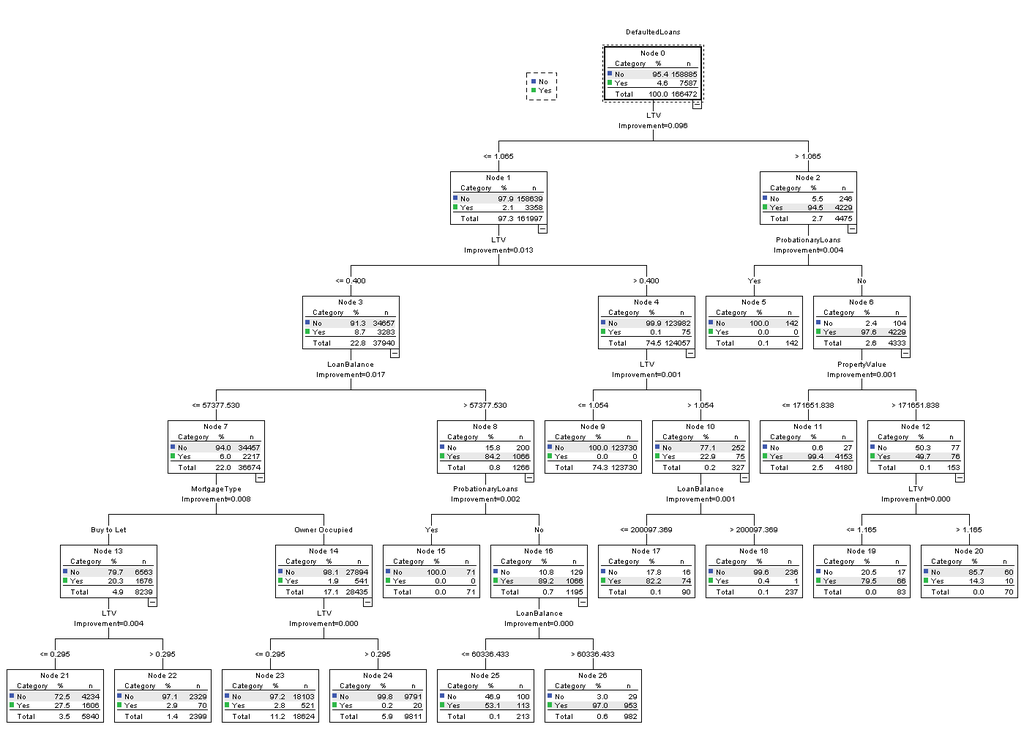

Test Sample  
Test Sample - Tree Diagram - July 26, 2017

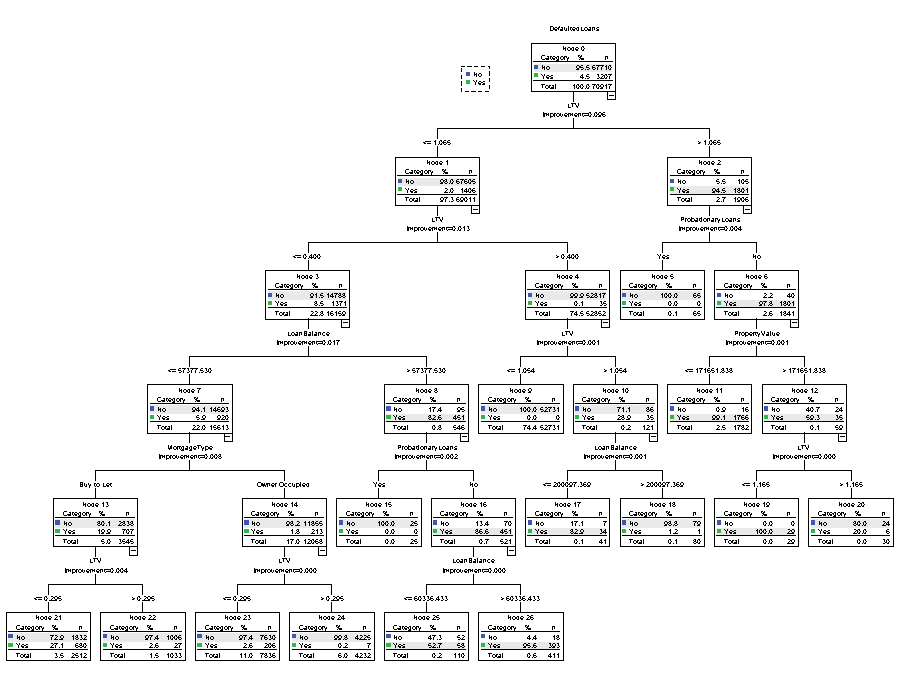

Classification Tree  
Classification Tree - Risk - July 26, 2017

RiskRisk, table, 1 levels of column headers and 1 levels of row headers, table with 3 columns and 5 rows

| Sample | Estimate | Std. Error |
| --- | --- | --- |
| Training | .015 | .000 |
| Test | .014 | .000 |

Growing Method: CRT Dependent Variable: DefaultedLoans

Classification Tree  
Classification Tree - Classification - July 26, 2017

ClassificationClassification, table, 2 levels of column headers and 2 levels of row headers, table with 5 columns and 10 rows

| Sample | Observed | Predicted |  |  |
| --- | --- | --- | --- | --- |
|  |  | No | Yes | Percent Correct |
| Training | No | 158696 | 189 | 99.9% |
|  | Yes | 2228 | 5359 | 70.6% |
|  | Overall Percentage | 96.7% | 3.3% | 98.5% |
| Test | No | 67617 | 93 | 99.9% |
|  | Yes | 927 | 2280 | 71.1% |
|  | Overall Percentage | 96.7% | 3.3% | 98.6% |

Growing Method: CRT Dependent Variable: DefaultedLoans

Log  
Log - Log - July 26, 2017

* Decision Tree.  
TREE DefaultedLoans [n] BY MortgageType [n] LoanBalance [s] InterestType [n] NewLoan [n]  
ProbationaryLoans [n] InterestIncome [s] PropertyValue [s] AnnualPYMT [s] AddressLatitude [s]  
AddressLongitude [s] County [n] LTV [s] ArrearsCategory [n] MortgageYears [s] InArrears [n]  
/TREE DISPLAY=TOPDOWN NODES=STATISTICS BRANCHSTATISTICS=YES NODEDEFS=YES SCALE=AUTO  
/DEPCATEGORIES USEVALUES=[VALID]  
/PRINT MODELSUMMARY CLASSIFICATION RISK CATEGORYSPECS  
/METHOD TYPE=EXHAUSTIVECHAID  
/GROWTHLIMIT MAXDEPTH=AUTO MINPARENTSIZE=100 MINCHILDSIZE=50  
/VALIDATION TYPE=SPLITSAMPLE(70) OUTPUT=BOTHSAMPLES  
/CHAID ALPHASPLIT=0.05 SPLITMERGED=NO CHISQUARE=PEARSON CONVERGE=0.001 MAXITERATIONS=100  
ADJUST=BONFERRONI INTERVALS=10  
/COSTS EQUAL  
/INFLUENCE CreditRating  
/MISSING NOMINALMISSING=MISSING.

Classification Tree  
Classification Tree - Notes - July 26, 2017

NotesNotes, table, 0 levels of column headers and 2 levels of row headers, table with 3 columns and 15 rows

| Output Created |  | 26-JUL-2017 21:47:58 |
| --- | --- | --- |
| Comments |  |  |
| Input | Active Dataset | DataSet1 |
|  | Filter | <none> |
|  | Weight | <none> |
|  | Split File | <none> |
|  | N of Rows in Working Data File | 237389 |
|  | Influence Variable | CreditRating |
| Missing Value Handling | Definition of Missing | Handling of user-defined missing values of nominal independent variables depends on the growing method. |
|  | Cases Used | Only cases with valid data for the dependent variable and some or all independent variables are used in computing any statistics. |
| Syntax |  | TREE DefaultedLoans [n] BY MortgageType [n] LoanBalance [s] InterestType [n] NewLoan [n] ProbationaryLoans [n] InterestIncome [s] PropertyValue [s] AnnualPYMT [s] AddressLatitude [s] AddressLongitude … |
| Resources | Processor Time | 00:00:22.36 |
|  | Elapsed Time | 00:00:26.02 |
| Files Saved | Rules File |  |

Classification Tree  
Classification Tree - Warnings - July 26, 2017

WarningsWarnings, table, 0 levels of column headers and 0 levels of row headers, table with 1 columns and 6 rows

| The table of scores is not displayed because the dependent variable is not ordinal. |
| --- |
| The table of priors is not displayed because the growing method is not QUEST or CRT. |
| The table of profits is not displayed because profits are not defined. |
| Gain summary Tables are not displayed because profits are undefined. |
| Target category gains tables are not displayed because target categories are undefined. |

Classification Tree  
Classification Tree - Model Summary - July 26, 2017

Model SummaryModel Summary, table, 0 levels of column headers and 2 levels of row headers, table with 3 columns and 12 rows

| Specifications | Growing Method | EXHAUSTIVE CHAID |
| --- | --- | --- |
|  | Dependent Variable | DefaultedLoans |
|  | Independent Variables | MortgageType, LoanBalance, InterestType, NewLoan, ProbationaryLoans, InterestIncome, PropertyValue, AnnualPYMT, AddressLatitude, AddressLongitude, County, LTV, ArrearsCategory, MortgageYears, InArrear… |
|  | Validation | Split Sample |
|  | Maximum Tree Depth | 3 |
|  | Minimum Cases in Parent Node | 100 |
|  | Minimum Cases in Child Node | 50 |
| Results | Independent Variables Included | LTV, MortgageType, ProbationaryLoans, InterestIncome, PropertyValue, LoanBalance, AnnualPYMT |
|  | Number of Nodes | 71 |
|  | Number of Terminal Nodes | 53 |
|  | Depth | 3 |

Classification Tree  
Classification Tree - Misclassification Costs - July 26, 2017

Misclassification CostsMisclassification Costs, table, 2 levels of column headers and 1 levels of row headers, table with 3 columns and 6 rows

| Observed | Predicted |  |
| --- | --- | --- |
|  | No | Yes |
| No | .000 | 1.000 |
| Yes | 1.000 | .000 |

Dependent Variable: DefaultedLoans

Training Sample  
Training Sample - Tree Diagram - July 26, 2017

[figure not shown]

Test Sample  
Test Sample - Tree Diagram - July 26, 2017

[figure not shown]

Classification Tree  
Classification Tree - Risk - July 26, 2017

RiskRisk, table, 1 levels of column headers and 1 levels of row headers, table with 3 columns and 5 rows

| Sample | Estimate | Std. Error |
| --- | --- | --- |
| Training | .019 | .000 |
| Test | .020 | .001 |

Growing Method: EXHAUSTIVE CHAID Dependent Variable: DefaultedLoans

Classification Tree  
Classification Tree - Classification - July 26, 2017

ClassificationClassification, table, 2 levels of column headers and 2 levels of row headers, table with 5 columns and 10 rows

| Sample | Observed | Predicted |  |  |
| --- | --- | --- | --- | --- |
|  |  | No | Yes | Percent Correct |
| Training | No | 157492 | 1197 | 99.2% |
|  | Yes | 1928 | 5623 | 74.5% |
|  | Overall Percentage | 95.9% | 4.1% | 98.1% |
| Test | No | 67332 | 574 | 99.2% |
|  | Yes | 868 | 2375 | 73.2% |
|  | Overall Percentage | 95.9% | 4.1% | 98.0% |

Growing Method: EXHAUSTIVE CHAID Dependent Variable: DefaultedLoans

[output not shown]

[output not shown]

[output not shown]

[output not shown]

[output not shown]

[output not shown]

[output not shown]

[output not shown]

[output not shown]